# Sea Level Rise

Flavius Mihai Bendres

2025-01-08

## **Introduction**

This project analyzes the global average sea level change since 1880. Using historical data from the US Environmental Protection Agency, I’ll create visualization models to predict sea level changes through 2050.

## **Data Import and EDA**

First, let’s import the data and examine its structure.

```r
sea_level_data <- read.csv("epa-sea-level.csv")

head(sea_level_data)
```

```
##   Year CSIRO.Adjusted.Sea.Level Lower.Error.Bound Upper.Error.Bound
## 1 2023                     null              null              null
## 2 2022                     null              null              null
## 3 2021                     null              null              null
## 4 2020                     null              null              null
## 5 2019                     null              null              null
## 6 2018                     null              null              null
##   NOAA.Adjusted.Sea.Level
## 1             10.20390442
## 2             9.974710764
## 3             9.886687548
## 4             9.699874064
## 5             9.594329444
## 6             9.340091693
```

```r
str(sea_level_data)
```

```
## 'data.frame':    144 obs. of  5 variables:
##  $ Year                    : int  2023 2022 2021 2020 2019 2018 2017 2016 2015 2014 ...
##  $ CSIRO.Adjusted.Sea.Level: chr  "null" "null" "null" "null" ...
##  $ Lower.Error.Bound       : chr  "null" "null" "null" "null" ...
##  $ Upper.Error.Bound       : chr  "null" "null" "null" "null" ...
##  $ NOAA.Adjusted.Sea.Level : chr  "10.20390442" "9.974710764" "9.886687548" "9.699874064" ...
```

```r
summary(sea_level_data)
```

```
##       Year      CSIRO.Adjusted.Sea.Level Lower.Error.Bound  Upper.Error.Bound
##  Min.   :1880   Length:144               Length:144         Length:144
##  1st Qu.:1916   Class :character         Class :character   Class :character
##  Median :1952   Mode  :character         Mode  :character   Mode  :character
##  Mean   :1952
##  3rd Qu.:1987
##  Max.   :2023
##  NOAA.Adjusted.Sea.Level
##  Length:144
##  Class :character
##  Mode  :character
##
##
##
```

## **Data Cleaning and Preparation**

Based on the structure output, we can see that there are several issues with the data: - Character columns that should be numeric - “null” values that need to be handled - Data ordering (most recent years first)

```r
sea_level_clean <- sea_level_data %>%
  mutate(across(c(CSIRO.Adjusted.Sea.Level, Lower.Error.Bound,
                  Upper.Error.Bound, NOAA.Adjusted.Sea.Level),
                ~ifelse(. == "null", NA, as.numeric(.))))
# Check the structure after conversion
str(sea_level_clean)
```

```
## 'data.frame':    144 obs. of  5 variables:
##  $ Year                    : int  2023 2022 2021 2020 2019 2018 2017 2016 2015 2014 ...
##  $ CSIRO.Adjusted.Sea.Level: num  NA NA NA NA NA NA NA NA NA NA ...
##  $ Lower.Error.Bound       : num  NA NA NA NA NA NA NA NA NA NA ...
##  $ Upper.Error.Bound       : num  NA NA NA NA NA NA NA NA NA NA ...
##  $ NOAA.Adjusted.Sea.Level : num  10.2 9.97 9.89 9.7 9.59 ...
```

```r
summary(sea_level_clean)
```

```
##       Year      CSIRO.Adjusted.Sea.Level Lower.Error.Bound Upper.Error.Bound
##  Min.   :1880   Min.   :-0.4409          Min.   :-1.346    Min.   :0.4646
##  1st Qu.:1916   1st Qu.: 1.6329          1st Qu.: 1.079    1st Qu.:2.2402
##  Median :1952   Median : 3.3130          Median : 2.915    Median :3.7106
##  Mean   :1952   Mean   : 3.6464          Mean   : 3.202    Mean   :4.0913
##  3rd Qu.:1987   3rd Qu.: 5.5876          3rd Qu.: 5.330    3rd Qu.:5.8455
##  Max.   :2023   Max.   : 9.2441          Max.   : 8.917    Max.   :9.5709
##                 NA's   :10               NA's   :10        NA's   :10
##  NOAA.Adjusted.Sea.Level
##  Min.   : 6.309
##  1st Qu.: 7.198
##  Median : 7.961
##  Mean   : 8.120
##  3rd Qu.: 9.127
##  Max.   :10.204
##  NA's   :113
```

```r
# NAs?
missing_values <- sea_level_clean %>%
  summarise(across(everything(), ~sum(is.na(.))))

# Display them
kable(missing_values) %>%
  kable_styling(bootstrap_options = c("striped", "hover", "condensed"))
```

| Year | CSIRO.Adjusted.Sea.Level | Lower.Error.Bound | Upper.Error.Bound | NOAA.Adjusted.Sea.Level |
| --- | --- | --- | --- | --- |
| 0 | 10 | 10 | 10 | 113 |

```r
# Check first and last available years for each source
csiro_years <- range(sea_level_clean$Year[!is.na(sea_level_clean$CSIRO.Adjusted.Sea.Level)])
noaa_years <- range(sea_level_clean$Year[!is.na(sea_level_clean$NOAA.Adjusted.Sea.Level)])

cat("CSIRO data available from", csiro_years[1], "to", csiro_years[2], "\n")
```

```
## CSIRO data available from 1880 to 2013
```

```r
cat("NOAA data available from", noaa_years[1], "to", noaa_years[2], "\n")
```

```
## NOAA data available from 1993 to 2023
```

```r
# Sort data chronologically for easier analysis
sea_level_clean <- sea_level_clean %>%
  arrange(Year)

head(sea_level_clean)
```

```
##   Year CSIRO.Adjusted.Sea.Level Lower.Error.Bound Upper.Error.Bound
## 1 1880                0.0000000        -0.9527559         0.9527559
## 2 1881                0.2204724        -0.7322835         1.1732283
## 3 1882               -0.4409449        -1.3464567         0.4645669
## 4 1883               -0.2322835        -1.1299213         0.6653543
## 5 1884                0.5905512        -0.2834646         1.4645669
## 6 1885                0.5314961        -0.3307087         1.3937008
##   NOAA.Adjusted.Sea.Level
## 1                      NA
## 2                      NA
## 3                      NA
## 4                      NA
## 5                      NA
## 6                      NA
```

Let’s check if there are any duplicate years:

```r
duplicates <- sea_level_clean %>%
  count(Year) %>%
  filter(n > 1)

if(nrow(duplicates) > 0) {
  cat("Duplicate years found:\n")
  print(duplicates)
} else {
  cat("No duplicate years found.\n")
}
```

```
## No duplicate years found.
```

```r
# Create a clean dataset with only the columns we need
sea_level_final <- sea_level_clean %>%
  select(Year, CSIRO.Adjusted.Sea.Level) %>%
  # Filter to include only years with CSIRO data - no NAs included
  filter(!is.na(CSIRO.Adjusted.Sea.Level))

summary(sea_level_final)
```

```
##       Year      CSIRO.Adjusted.Sea.Level
##  Min.   :1880   Min.   :-0.4409
##  1st Qu.:1913   1st Qu.: 1.6329
##  Median :1946   Median : 3.3130
##  Mean   :1946   Mean   : 3.6464
##  3rd Qu.:1980   3rd Qu.: 5.5876
##  Max.   :2013   Max.   : 9.2441
```

```r
cat("First few rows:\n")
```

```
## First few rows:
```

```r
head(sea_level_final)
```

```
##   Year CSIRO.Adjusted.Sea.Level
## 1 1880                0.0000000
## 2 1881                0.2204724
## 3 1882               -0.4409449
## 4 1883               -0.2322835
## 5 1884                0.5905512
## 6 1885                0.5314961
```

```r
cat("\nLast few rows:\n")
```

```
##
## Last few rows:
```

```r
tail(sea_level_final)
```

```
##     Year CSIRO.Adjusted.Sea.Level
## 129 2008                 8.303150
## 130 2009                 8.531496
## 131 2010                 8.834646
## 132 2011                 8.897638
## 133 2012                 9.244094
## 134 2013                 8.913386
```

## **4. Visualization**

Now that we have clean data, let’s explore it visually:

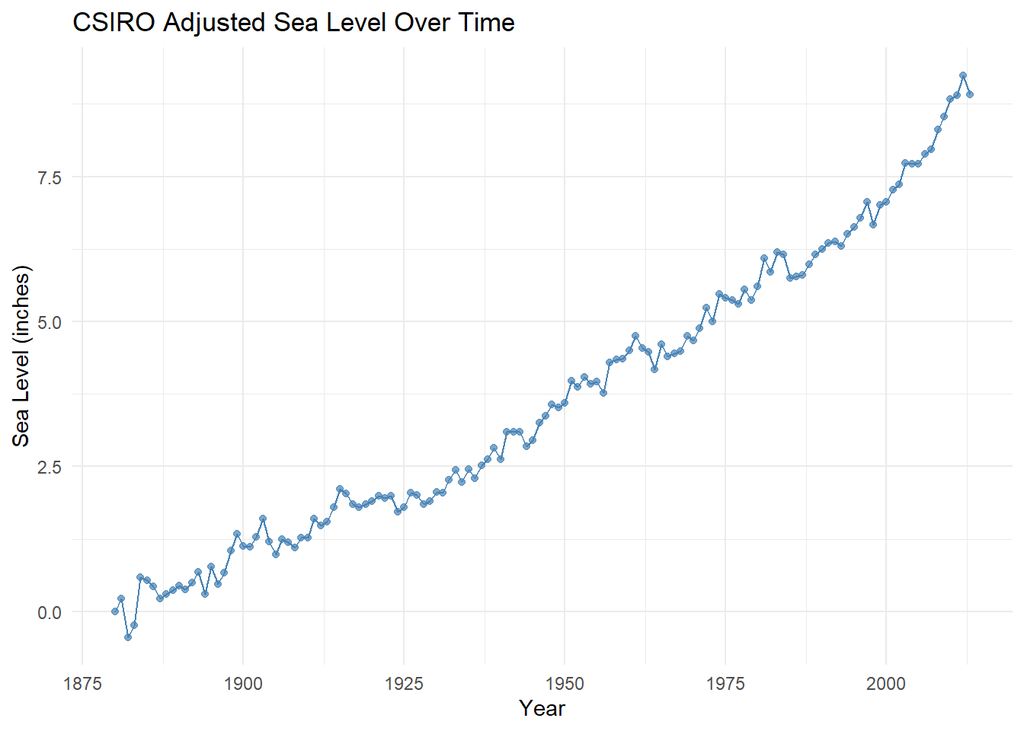

```r
ggplot(sea_level_final, aes(x = Year, y = CSIRO.Adjusted.Sea.Level)) +
  geom_line(color = "steelblue") +
  geom_point(color = "steelblue", alpha = 0.7) +
  labs(
    title = "CSIRO Adjusted Sea Level Over Time",
    x = "Year",
    y = "Sea Level (inches)"
  ) +
  theme_minimal()
```

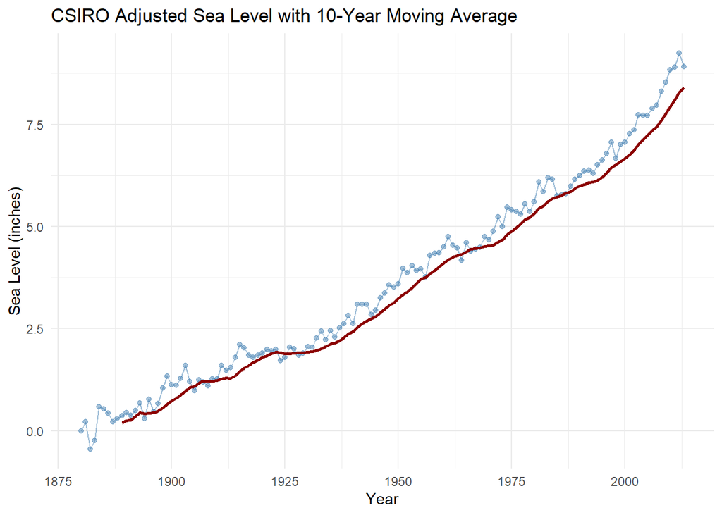

```r
#  10-year moving average
sea_level_final <- sea_level_final %>%
  arrange(Year) %>%
  mutate(
    moving_avg_10yr = zoo::rollmean(CSIRO.Adjusted.Sea.Level, k = 10, fill = NA, align = "right")
  )

# Plot with moving average
ggplot(sea_level_final, aes(x = Year)) +
  geom_line(aes(y = CSIRO.Adjusted.Sea.Level), color = "steelblue", alpha = 0.5) +
  geom_point(aes(y = CSIRO.Adjusted.Sea.Level), color = "steelblue", alpha = 0.5) +
  geom_line(aes(y = moving_avg_10yr), color = "darkred", linewidth = 1) +
  labs(
    title = "CSIRO Adjusted Sea Level with 10-Year Moving Average",
    x = "Year",
    y = "Sea Level (inches)"
  ) +
  theme_minimal()
```

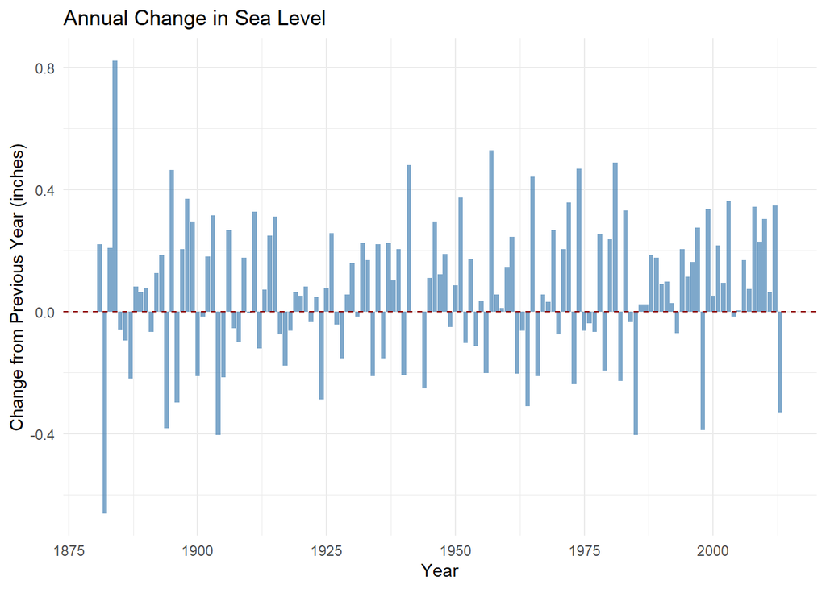

```r
#  rate of change year by year
sea_level_final <- sea_level_final %>%
  mutate(
    annual_change = c(NA, diff(CSIRO.Adjusted.Sea.Level))
  )

# Plot rate of change
ggplot(sea_level_final, aes(x = Year, y = annual_change)) +
  geom_bar(stat = "identity", fill = "steelblue", alpha = 0.7) +
  geom_hline(yintercept = 0, linetype = "dashed", color = "darkred") +
  labs(
    title = "Annual Change in Sea Level",
    x = "Year",
    y = "Change from Previous Year (inches)"
  ) +
  theme_minimal()
```

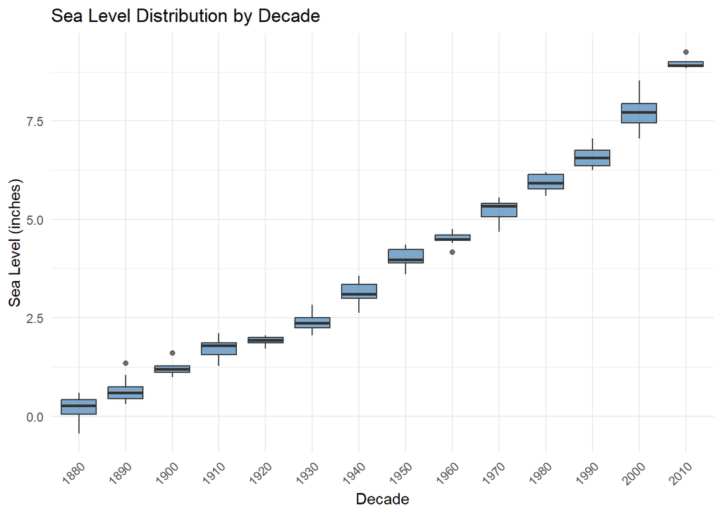

```r
# decade groups for boxplot analysis
sea_level_final <- sea_level_final %>%
  mutate(decade = floor(Year / 10) * 10)

# Boxplots by decade
ggplot(sea_level_final, aes(x = as.factor(decade), y = CSIRO.Adjusted.Sea.Level)) +
  geom_boxplot(fill = "steelblue", alpha = 0.7) +
  labs(
    title = "Sea Level Distribution by Decade",
    x = "Decade",
    y = "Sea Level (inches)"
  ) +
  theme_minimal() +
  theme(axis.text.x = element_text(angle = 45, hjust = 1))
```

## **5. Linear Regression Analysis**

### 5.1 Model 1: Using All Available Data

OLS using all available CSIRO data:

```r
model_full <- lm(CSIRO.Adjusted.Sea.Level ~ Year, data = sea_level_final)

summary(model_full)
```

```
##
## Call:
## lm(formula = CSIRO.Adjusted.Sea.Level ~ Year, data = sea_level_final)
##
## Residuals:
##      Min       1Q   Median       3Q      Max
## -0.69092 -0.30470 -0.05892  0.23556  1.47928
##
## Coefficients:
##               Estimate Std. Error t value Pr(>|t|)
## (Intercept) -1.187e+02  1.845e+00  -64.37   <2e-16 ***
## Year         6.288e-02  9.475e-04   66.36   <2e-16 ***
## ---
## Signif. codes:  0 '***' 0.001 '**' 0.01 '*' 0.05 '.' 0.1 ' ' 1
##
## Residual standard error: 0.4243 on 132 degrees of freedom
## Multiple R-squared:  0.9709, Adjusted R-squared:  0.9707
## F-statistic:  4404 on 1 and 132 DF,  p-value: < 2.2e-16
```

```r
# model metrics
model_full_metrics <- glance(model_full)
kable(model_full_metrics) %>%
  kable_styling(bootstrap_options = c("striped", "hover", "condensed"))
```

| r.squared | adj.r.squared | sigma | statistic | p.value | df | logLik | AIC | BIC | deviance | df.residual | nobs |
| --- | --- | --- | --- | --- | --- | --- | --- | --- | --- | --- | --- |
| 0.970898 | 0.9706776 | 0.4242584 | 4403.776 | 0 | 1 | -74.23695 | 154.4739 | 163.1674 | 23.75937 | 132 | 134 |

```r
# Extract slope and intercept
slope_full <- coef(model_full)[2]
intercept_full <- coef(model_full)[1]

cat("The slope of the full model is", round(slope_full, 4),
    "inches per year, which equals", round(slope_full * 100, 2),
    "inches per century.\n")
```

```
## The slope of the full model is 0.0629 inches per year, which equals 6.29 inches per century.
```

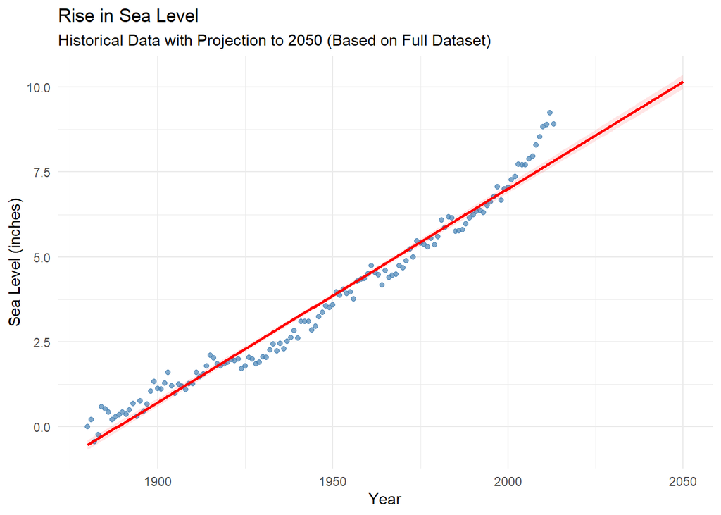

```r
# data frame for prediction through 2050
future_years <- data.frame(Year = seq(min(sea_level_final$Year), 2050))

# predictions with confidence intervals
predictions_full <- predict(model_full, newdata = future_years, interval = "confidence")
future_predictions_full <- cbind(future_years, as.data.frame(predictions_full))

# Plot with regression line extended to 2050
ggplot() +
  geom_point(data = sea_level_final, aes(x = Year, y = CSIRO.Adjusted.Sea.Level),
             color = "steelblue", alpha = 0.7) +
  geom_line(data = future_predictions_full, aes(x = Year, y = fit),
            color = "red", size = 1) +
  geom_ribbon(data = future_predictions_full,
              aes(x = Year, ymin = lwr, ymax = upr),
              fill = "red", alpha = 0.1) +
  labs(
    title = "Rise in Sea Level",
    subtitle = "Historical Data with Projection to 2050 (Based on Full Dataset)",
    x = "Year",
    y = "Sea Level (inches)"
  ) +
  theme_minimal()
```

### **5.2 Model 2: Using Recent Data (2000 Onwards)**

```r
# the cutoff year for recent data
if(max(sea_level_final$Year) >= 2000) {
  recent_cutoff <- 2000
  recent_label <- "2000-Present"
} else {
  # If no data after 2000, use most recent 20 years or half the dataset, whichever is smaller
  years_range <- max(sea_level_final$Year) - min(sea_level_final$Year)
  if(years_range >= 40) {
    recent_cutoff <- max(sea_level_final$Year) - 20
    recent_label <- paste0("Most recent 20 years (", recent_cutoff, "-", max(sea_level_final$Year), ")")
  } else {
    recent_cutoff <- min(sea_level_final$Year) + floor(years_range/2)
    recent_label <- paste0("Most recent half of data (", recent_cutoff, "-", max(sea_level_final$Year), ")")
  }
}

recent_data <- sea_level_final %>% filter(Year >= recent_cutoff)

cat("Using recent data from", recent_cutoff, "to", max(recent_data$Year), "\n")
```

```
## Using recent data from 2000 to 2013
```

```r
cat("Number of data points in recent data:", nrow(recent_data), "\n")
```

```
## Number of data points in recent data: 14
```

Now let’s create a model using only the recent data:

```r
# linear model using recent data
model_recent <- lm(CSIRO.Adjusted.Sea.Level ~ Year, data = recent_data)

# Display model summary
summary(model_recent)
```

```
##
## Call:
## lm(formula = CSIRO.Adjusted.Sea.Level ~ Year, data = recent_data)
##
## Residuals:
##       Min        1Q    Median        3Q       Max
## -0.235433 -0.111361  0.007394  0.067377  0.256399
##
## Coefficients:
##               Estimate Std. Error t value Pr(>|t|)
## (Intercept) -315.19204   20.49712  -15.38 2.92e-09 ***
## Year           0.16112    0.01022   15.77 2.19e-09 ***
## ---
## Signif. codes:  0 '***' 0.001 '**' 0.01 '*' 0.05 '.' 0.1 ' ' 1
##
## Residual standard error: 0.1541 on 12 degrees of freedom
## Multiple R-squared:  0.954,  Adjusted R-squared:  0.9501
## F-statistic: 248.8 on 1 and 12 DF,  p-value: 2.185e-09
```

```r
# Get model metrics
model_recent_metrics <- glance(model_recent)
kable(model_recent_metrics) %>%
  kable_styling(bootstrap_options = c("striped", "hover", "condensed"))
```

| r.squared | adj.r.squared | sigma | statistic | p.value | df | logLik | AIC | BIC | deviance | df.residual | nobs |
| --- | --- | --- | --- | --- | --- | --- | --- | --- | --- | --- | --- |
| 0.9539837 | 0.950149 | 0.154079 | 248.7769 | 0 | 1 | 7.39797 | -8.79594 | -6.878768 | 0.2848842 | 12 | 14 |

```r
# slope and intercept
slope_recent <- coef(model_recent)[2]
intercept_recent <- coef(model_recent)[1]

cat("The slope of the recent model is", round(slope_recent, 4),
    "inches per year, which equals", round(slope_recent * 100, 2),
    "inches per century.\n")
```

```
## The slope of the recent model is 0.1611 inches per year, which equals 16.11 inches per century.
```

```r
cat("The slope of the recent model is",
    ifelse(slope_recent > slope_full, "steeper", "less steep"),
    "than the full model, indicating sea level rise is",
    ifelse(slope_recent > slope_full, "accelerating", "decelerating"),
    "in recent years.\n")
```

```
## The slope of the recent model is steeper than the full model, indicating sea level rise is accelerating in recent years.
```

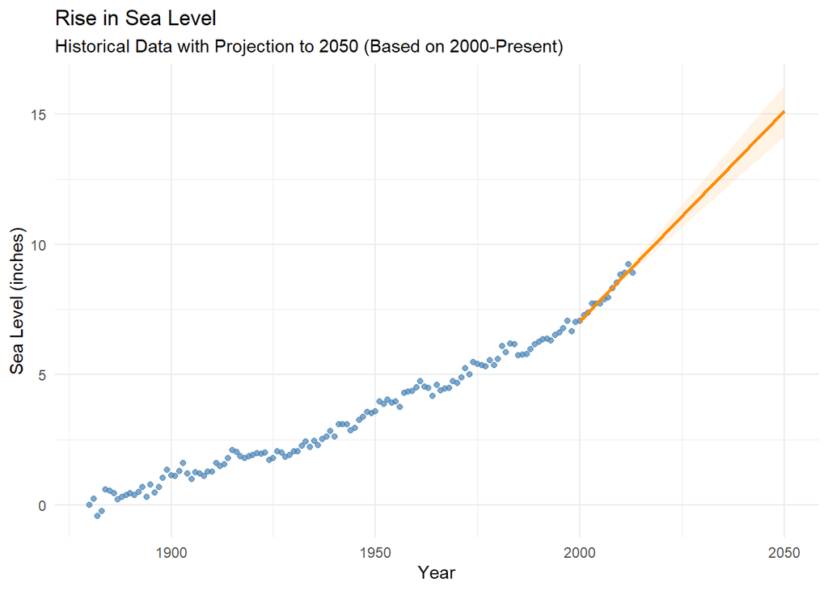

```r
# data frame for prediction through 2050
future_years_recent <- data.frame(Year = seq(recent_cutoff, 2050))

# predictions with confidence intervals
predictions_recent <- predict(model_recent, newdata = future_years_recent, interval = "confidence")
future_predictions_recent <- cbind(future_years_recent, as.data.frame(predictions_recent))

# Plot with regression line extended to 2050
ggplot() +
  geom_point(data = sea_level_final, aes(x = Year, y = CSIRO.Adjusted.Sea.Level),
             color = "steelblue", alpha = 0.7) +
  geom_line(data = future_predictions_recent, aes(x = Year, y = fit),
            color = "darkorange", size = 1) +
  geom_ribbon(data = future_predictions_recent,
              aes(x = Year, ymin = lwr, ymax = upr),
              fill = "darkorange", alpha = 0.1) +
  labs(
    title = "Rise in Sea Level",
    subtitle = paste0("Historical Data with Projection to 2050 (Based on ", recent_label, ")"),
    x = "Year",
    y = "Sea Level (inches)"
  ) +
  theme_minimal()
```

## **6. Combined Visualization and Predictions**

Creating a final visualization that combines both models:

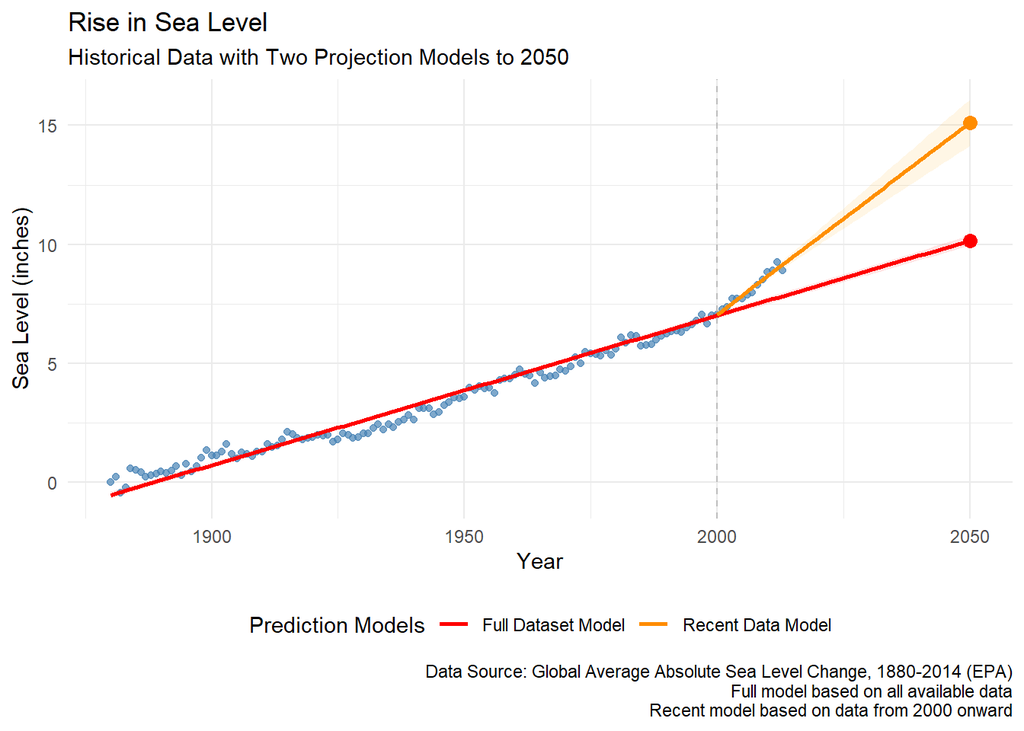

```r
ggplot() +
  # Historical data points
  geom_point(data = sea_level_final, aes(x = Year, y = CSIRO.Adjusted.Sea.Level),
             color = "steelblue", alpha = 0.7) +

  # Line for full model
  geom_line(data = future_predictions_full, aes(x = Year, y = fit, color = "Full Dataset Model"),
            size = 1) +
  geom_ribbon(data = future_predictions_full,
              aes(x = Year, ymin = lwr, ymax = upr),
              fill = "red", alpha = 0.1) +

  # Line for recent model
  geom_line(data = future_predictions_recent, aes(x = Year, y = fit, color = "Recent Data Model"),
            size = 1) +
  geom_ribbon(data = future_predictions_recent,
              aes(x = Year, ymin = lwr, ymax = upr),
              fill = "orange", alpha = 0.1) +

  # Highlighting predicted values for 2050
  geom_point(aes(x = 2050, y = future_predictions_full[future_predictions_full$Year == 2050, "fit"]),
             color = "red", size = 3) +
  geom_point(aes(x = 2050, y = future_predictions_recent[future_predictions_recent$Year == 2050, "fit"]),
             color = "darkorange", size = 3) +

  # vertical line at recent cutoff
  geom_vline(xintercept = recent_cutoff, linetype = "dashed", color = "gray") +

  # Formatting
  scale_color_manual(name = "Prediction Models",
                     values = c("Full Dataset Model" = "red", "Recent Data Model" = "darkorange")) +
  labs(
    title = "Rise in Sea Level",
    subtitle = "Historical Data with Two Projection Models to 2050",
    x = "Year",
    y = "Sea Level (inches)",
    caption = paste0("Data Source: Global Average Absolute Sea Level Change, 1880-2014 (EPA)\n",
                     "Full model based on all available data\n",
                     "Recent model based on data from ", recent_cutoff, " onward")
  ) +
  theme_minimal() +
  theme(legend.position = "bottom") +
  coord_cartesian(xlim = c(min(sea_level_final$Year), 2050))
```

```r
ggsave("sea_level_predictor.png", width = 10, height = 6, dpi = 300)
```

```r
# Extract predictions for 2050
prediction_2050_full <- future_predictions_full[future_predictions_full$Year == 2050, ]
prediction_2050_recent <- future_predictions_recent[future_predictions_recent$Year == 2050, ]

# Create a data frame for comparison
predictions_2050 <- data.frame(
  Model = c("Full Dataset Model", "Recent Data Model"),
  Prediction = c(prediction_2050_full$fit, prediction_2050_recent$fit),
  Lower_CI = c(prediction_2050_full$lwr, prediction_2050_recent$lwr),
  Upper_CI = c(prediction_2050_full$upr, prediction_2050_recent$upr)
)

#  change from earliest year
earliest_year <- min(sea_level_final$Year)
earliest_level <- sea_level_final$CSIRO.Adjusted.Sea.Level[sea_level_final$Year == earliest_year]

predictions_2050$Change_Since_First <- predictions_2050$Prediction - earliest_level
predictions_2050$Change_Since_First_Percentage <- (predictions_2050$Change_Since_First / earliest_level) * 100

#  change from 2000 or most recent year before 2000
if(any(sea_level_final$Year <= 2000)) {
  reference_year <- max(sea_level_final$Year[sea_level_final$Year <= 2000])
} else {
  reference_year <- min(sea_level_final$Year)
}
reference_level <- sea_level_final$CSIRO.Adjusted.Sea.Level[sea_level_final$Year == reference_year]

predictions_2050$Change_Since_Reference <- predictions_2050$Prediction - reference_level
predictions_2050$Reference_Year <- reference_year

# Display the comparison
kable(predictions_2050) %>%
  kable_styling(bootstrap_options = c("striped", "hover", "condensed"))
```

| Model | Prediction | Lower_CI | Upper_CI | Change_Since_First | Change_Since_First_Percentage | Change_Since_Reference | Reference_Year |
| --- | --- | --- | --- | --- | --- | --- | --- |
| Full Dataset Model | 10.15413 | 9.947037 | 10.36121 | 10.15413 | Inf | 3.099007 | 2000 |
| Recent Data Model | 15.11037 | 14.138033 | 16.08272 | 15.11037 | Inf | 8.055257 | 2000 |

```r
#  the difference between models
difference <- prediction_2050_recent$fit - prediction_2050_full$fit
cat("The difference between the two model predictions for 2050 is",
    round(difference, 2), "inches.\n")
```

```
## The difference between the two model predictions for 2050 is 4.96 inches.
```

```r
if(prediction_2050_recent$lwr > prediction_2050_full$upr ||
   prediction_2050_recent$upr < prediction_2050_full$lwr) {
  cat("This difference is statistically significant as the confidence intervals do not overlap.\n")
} else {
  cat("This difference is not statistically significant as the confidence intervals overlap.\n")
}
```

```
## This difference is statistically significant as the confidence intervals do not overlap.
```

```r
#  key statistics
full_model_rise_per_century <- slope_full * 100
recent_model_rise_per_century <- slope_recent * 100
acceleration_factor <- slope_recent / slope_full

cat("Key findings:\n")
```

```
## Key findings:
```

```r
cat("1. Sea level rise rate from full historical data:", round(full_model_rise_per_century, 2), "inches per century\n")
```

```
## 1. Sea level rise rate from full historical data: 6.29 inches per century
```

```r
cat("2. Sea level rise rate from recent data:", round(recent_model_rise_per_century, 2), "inches per century\n")
```

```
## 2. Sea level rise rate from recent data: 16.11 inches per century
```

```r
cat("3. Acceleration factor:", round(acceleration_factor, 2), "\n")
```

```
## 3. Acceleration factor: 2.56
```

```r
cat("4. Projected sea level in 2050 (full model):", round(prediction_2050_full$fit, 2), "inches\n")
```

```
## 4. Projected sea level in 2050 (full model): 10.15 inches
```

```r
cat("5. Projected sea level in 2050 (recent model):", round(prediction_2050_recent$fit, 2), "inches\n")
```

```
## 5. Projected sea level in 2050 (recent model): 15.11 inches
```

## **Key Takeaways**

Historical Trend: The data clearly shows a consistent upward trend in sea levels since measurements began. The full dataset model indicates an average rise of approximately 6.29 inces inches per century. Recent Acceleration: The model based on more recent data shows a steeper slope, indicating an acceleration in the rate of sea level rise. The recent model suggests a rise of approximately 16.11 inches per century, which is 2.56 times faster than the historical average. Projections for 2050:

Based on the full historical dataset, sea levels are projected to reach approximately 10.15 inches by 2050. Based on recent trends, sea levels could reach approximately 15.11 inches by 2050. The difference between these two projections 4.96 inches highlights the importance of considering accelerating trends in climate models.

The widening confidence intervals as we project further into the future reflect the increasing uncertainty in long-term predictions. This is particularly evident in the recent data model, which has fewer data points.

If the recent acceleration in sea level rise continues, coastal communities may face more significant challenges than would be predicted by models based on the full historical record. This underscores the importance of ongoing monitoring and potentially more aggressive mitigation strategies.

## **Limitations**

Linear Modeling: We’ve used simple linear regression, which assumes a constant rate of change. In reality, sea level rise may follow more complex patterns due to feedback mechanisms in the climate system. Data Availability: The analysis is limited by the available data. Any gaps or inconsistencies in the historical record could affect our results. External Factors: Our models don’t explicitly account for potential future changes in factors that influence sea level rise, such as greenhouse gas emissions, ice sheet dynamics, or climate policies. Regional Variations: This analysis focuses on global average sea level change. Regional variations can be significant, with some areas experiencing more rapid rise than others due to local factors.

## **Conclusion**

Sea levels have risen consistently, with recent data showing an acceleration in the rate of rise. Projections based on recent trends suggest a more significant rise than those using long-term historical data, emphasizing the need for coastal communities, planners, and policymakers to prepare accordingly. Continued monitoring, research, and adaptive management are vital to understanding and addressing evolving sea level dynamics.

###**References** Global Average Absolute Sea Level Change, 1880-2014 from the US Environmental Protection Agency using data from CSIRO, 2015; NOAA, 2015. R Core Team (2021). R: A language and environment for statistical computing. R Foundation for Statistical Computing, Vienna, Austria. URL https://www.R-project.org/. Wickham H, Averick M, Bryan J, Chang W, McGowan LD, François R, Grolemund G, Hayes A, Henry L, Hester J, Kuhn M, Pedersen TL, Miller E, Bache SM, Müller K, Ooms J, Robinson D, Seidel DP, Spinu V, Takahashi K, Vaughan D, Wilke C, Woo K, Yutani H (2019). “Welcome to the tidyverse.” Journal of Open Source Software, 4(43), 1686. doi:10.21105/joss.01686.

## **Learning Outcomes and ideas I learned in this project**

### Packages

Working on this project introduced several useful R packages:

#### kableExtra

**What it is:** An extension to the `kable` function in R that enhances table formatting capabilities.

**What it does:** kableExtra provides a simple but powerful way to create elegant, publication-quality tables in R Markdown documents. It allows for: - Custom styling with bootstrap themes - Row and column highlighting - Cell formatting options - Table captions and footnotes - Advanced conditional formatting

**Learning value:** Using kableExtra improved the presentation of tabular data in the report, making it more readable and professional. This is a valuable skill for creating reports that communicate findings effectively to both technical and non-technical audiences.

#### broom

The `broom` package was helpful for converting statistical model outputs into tidy data frames, making it easier to extract and visualize model parameters.

#### zoo

The `zoo` package’s `rollmean()` function allowed for easy calculation of moving averages, providing insights into trends by smoothing out short-term fluctuations.

### Effective Data Visualization

The project provided practice in creating meaningful visualizations beyond basic plotting: - Incorporating confidence intervals as shaded regions - Combining multiple layers of information in a single plot

### Critical Thinking About Climate Data

Working with climate data required careful consideration of: - The implications of linear vs. non-linear trends - The appropriate time frames for analysis - How to communicate uncertainty in projections - The practical implications of statistical findings

These considerations are essential when working with data that has significant real-world implications.